# Counterfactual: An R Package for Counterfactual Analysis

The *Counterfactual* package implements the estimation and inference methods of Chernozhukov et al. (2013) for counterfactual analysis. The counterfactual distributions considered are the result of changing either the marginal distribution of covariates related to the outcome variable of interest, or the conditional distribution of the outcome given the covariates. They can be applied to estimate quantile treatment effects and wage decompositions. This paper serves as an introduction to the package and displays basic functionality of the commands contained within.

Mingli Chen (Department of Economics, University of Warwick) , Victor Chernozhukov (Department of Economics, Massachusetts Institute of Technology) , Iván Fernández-Val (Department of Economics, Boston University) , Blaise Melly (Department of Economics, University of Bern)  
2017-06-08

## 1 Introduction

Using econometric terminology, we can often think of a counterfactual distribution as the result of a change in either the distribution of a set of covariates $X$ that determine the outcome variable of interest $Y$, or the relationship of the covariates with the outcomes, that is, a change in the conditional distribution of $Y$ given $X$. Counterfactual analysis consists of evaluating the effects of such changes. The [*Counterfactual*](https://CRAN.R-project.org/package=Counterfactual) package implements the methods of (Chernozhukov et al. 2013) for counterfactual analysis. It contains commands to estimate and make inference on quantile effects constructed from counterfactual distributions. The counterfactual distributions are estimated using regression methods such as classical, duration, quantile and distribution regressions. The inference on the quantile effect function can be pointwise at a specific quantile index or uniform over a range of specified quantile indexes.

We start by giving a simple example of counterfactual analysis. Suppose we would like to analyze the wage differences between men and women. Let $0$ denote the population of men and let $1$ denote the population of women. The variable $Y_{j}$ denotes wages and $X_{j}$ denotes job market-relevant characteristics that affect wages for populations $j=0$ and $j=1$. The conditional distribution functions $F_{Y_0|X_0}(y|x)$ and $F_{Y_1|X_1}(y|x)$ describe the stochastic assignment of wages to workers with characteristics $x$, for men and women, respectively. Let $F_{Y\left\langle 0|0\right\rangle }$ and $F_{Y\left\langle 1|1\right\rangle }$ represent the observed distribution function of wages for men and women, and let $F_{Y\left\langle 0|1\right\rangle }$ represent the distribution function of wages that would have prevailed for women had they faced the men’s wage schedule $F_{Y_0|X_0}$:
$$\label{eq:DefCounter} F_{Y\left\langle 0|1\right\rangle }(y):=\int_{\mathcal{X}_{1}}F_{Y_{0}|X_{0}}(y|x)dF_{X_{1}}(x).
\tag{1}$$
The latter distribution is called counterfactual, since it does not arise as a distribution from any observable population. Rather, this distribution is constructed by integrating the conditional distribution of wages for men with respect to the distribution of characteristics for women. This quantity is well defined if $\mathcal{X}_0$, the support of men’s characteristics, includes $\mathcal{X}_1$, the support of women’s characteristics, namely $\mathcal{X}_1\subset \mathcal{X}_0$.

Let $F^{\leftarrow}$ denote the quantile or left-inverse function of the distribution function $F$. The difference in the observed wage quantile function between men and women can be decomposed in the spirit of (Oaxaca 1973) and (Blinder 1973) as
$$\label{eq:decomp}
F^{\leftarrow}_{Y\left\langle 1|1\right\rangle }-F^{\leftarrow}_{Y\left\langle 0|0\right\rangle}=[F^{\leftarrow}_{Y\left\langle 1|1\right\rangle}-F^{\leftarrow}_{Y\left\langle 0|1\right\rangle}]+[F^{\leftarrow}_{Y\left\langle 0|1\right\rangle }-F^{\leftarrow}_{Y\left\langle 0|0\right\rangle }], \tag{2}$$
where the first term in brackets is due to differences in the wage structure and the second term is a composition effect due to differences in characteristics. These counterfactual effects are well defined econometric parameters and are widely used in empirical analysis, for example, the first term of the decomposition is a measure of gender wage discrimination. In Section 3.2 we consider an empirical example where $0$ denotes the population of nonunion workers and $1$ denotes the population of union workers. In this case the the wage structure effect corresponds to the treatment effect of union or union premium. It is important to note that these effects do not necessarily have a causal interpretation without additional conditions that are spelled out in (Chernozhukov et al. 2013).

## 2 The Counterfactual package

### 2.1 Getting started

To get started using the package *Counterfactual* for the first time, issue the command

```r
> install.packages("Counterfactual")
```

into your R browser to install the package in your computer. Once the package has been installed, you can use the package *Counterfactual* during any R session by simply issuing the command

```r
> library(Counterfactual)
```

Now you are ready to use the function *counterfactual* and data sets contained in *Counterfactual*. For general questions about the package you may type

```r
> help(package = "Counterfactual")
```

to view the package help file, or for more questions about a specific function you can type `help(function-name)`. For example, try:

```r
> help(counterfactual)
```

or simply type

```r
> ?counterfactual
```

The command *counterfactual* has the general syntax:

```r
> counterfactual(formula, data, weights, na.action = na.exclude,
+                group, treatment = FALSE, decomposition = FALSE,
+                transformation = FALSE, counterfactual_var,
+                quantiles, method = "qr",
+                trimming = 0.005, nreg = 100, scale_variable,
+                counterfactual_scale_variable,
+                censoring = 0, right = FALSE, nsteps = 3,
+                firstc = 0.1, secondc = 0.05, noboot = FALSE,
+                weightedboot = FALSE, seed = 8, robust = FALSE,
+                reps = 100, alpha = 0.05, first = 0.1,
+                last = 0.9, cons_test = 0, printdeco = TRUE,
+                sepcore = FALSE, ncore=1)
```

To describe the different options of the command we need to provide some background on methods for counterfactual analysis.

### 2.2 Setting for counterfactual analysis

Consider a general setting with two populations labeled by $k\in \mathcal{K} = \{0,1\}$. For each population $k$ there is the $% d_{x}$-vector $X_{k}$ of covariates and the scalar outcome $Y_{k}$. The covariate vector is observable in all populations, but the outcome is only observable in populations $j\in \mathcal{J}\subseteq \mathcal{K}$. Let $F_{X_{k}}$ denote the covariate distribution in population $k\in \mathcal{K},$ and $% F_{Y_{j}|X_{j}}$ and $Q_{Y_{j}|X_{j}}$ denote the conditional distribution and quantile functions in population $j\in \mathcal{J}$. We denote the support of $X_{k}$ by $% \mathcal{X}_{k}\subseteq \mathbb{R}^{d_{x}}$, and the region of interest for $% Y_{j}$ by $\mathcal{Y}_{j}\subseteq \mathbb{R}$. The refer to $j$ as the reference population(s) and to $k$ as the counterfactual population(s).

The reference and counterfactual populations in the wage examples correspond to different groups such as men and women or nonunion and union workers. We can also generate counterfactual populations by artificially transforming a reference population. Formally, we can think of $X_k$ as being created through a known transformation of $X_j$:
$$\label{eq:transform}
X_{k}=g_{k}(X_{j}),\quad\mathrm{where}\quad g_{k}:\mathcal{X}_{j}\rightarrow\mathcal{X}_{k}. \tag{3}$$
This case covers adding one unit to the first covariate, $X_{1,k}=X_{1,j}+1$, holding the rest of the covariates constant. The resulting quantile effect becomes the *unconditional* quantile regression, which measures the effect of a unit change in a given covariate component on the unconditional quantiles of $Y$. For example, this type of counterfactual is useful for estimating the treatment effect of smoking during pregnancy on infant birth weights. Another possible transformation is a mean preserving redistribution of the first covariate implemented as $X_{1,k} = (1-\alpha) E[X_{1,j}] + \alpha X_{1,j}$. These and more general types of transformation defined in ((3)) are useful for estimating the effect of a change in taxation on the marginal distribution of food expenditure or the effect of cleaning up a local hazardous waste site on the marginal distribution of housing prices ((Stock 1991)). We give an example of this type of transformation in Section 3.1.

The reference and counterfactual populations can be specified to *counterfactual* in two ways that accommodate the previous two cases:

Counterfactual distribution and quantile functions are formed by combining the conditional distribution in the population $j$ with the covariate distribution in the population $k$, namely:
$$\begin{aligned}
& F_{Y{\langle j|k\rangle }}(y):=\int_{\mathcal{X}%
_{k}}F_{Y_{j}|X_{j}}(y|x)dF_{X_{k}}(x),\ \ y\in \mathcal{Y}_{j},
\\
& Q_{Y{\langle j|k\rangle }}(\tau ):=F_{Y{\langle j|k\rangle }}^{\leftarrow
}(\tau ),\ \ \tau \in (0,1),\label{define:counter}
\end{aligned} \tag{4}$$
where $(j,k) \in \mathcal{J}\mathcal{K}$, and $F_{Y{\langle j|k\rangle }}^{\leftarrow }(\tau) = \inf \{y \in \mathcal{Y}_{j}: F_{Y{\langle j|k\rangle }}(y) \geq \tau \}$ is the left-inverse function of $F_{Y{\langle j|k\rangle }}$. The main interest lies in the quantile effect (QE) function, defined as the difference of two counterfactual quantile functions over a set of quantile indexes $\mathcal{T} \subset (0,1)$:
$$\Delta(\tau) = Q_{Y{\langle j|k\rangle }}(\tau ) - Q_{Y{\langle j|j \rangle }}(\tau ), \ \tau \in \mathcal{T},$$
where $j \in \mathcal{J}$ and $k \in \mathcal{K}$. In the example of Section 1, we obtain the composition effect with $j=0$ and $k=1$. When $Y_k$ is observed, then we can construct the structure effect or treatment effect on the treated
$$\Delta(\tau) = Q_{Y{\langle k|k \rangle }}(\tau ) - Q_{Y{\langle j|k \rangle }}(\tau ), \ \tau \in \mathcal{T},$$
by specifying the option *group* and setting *treatment=TRUE*. In the example of Section 1, we obtain the wage structure effect with $j=0$ and $k=1$, i.e. setting *group=1* and *treatment=TRUE*. If in addition we select the option *decomposition=TRUE*, then we obtain the entire decomposition ((2)) including the composition, structure and total effects. The total effect is
$$\Delta(\tau) = Q_{Y{\langle k|k \rangle }}(\tau ) - Q_{Y{\langle j|j \rangle }}(\tau ), \ \tau \in \mathcal{T}.$$
The set $\mathcal{T}$ is specified with the option *quantiles*, which enumerates the quantile indexes of interested and should be a vector containing numbers between 0 and 1.

To estimate the QE function we need to model and estimate the conditional distribution $F_{Y_{j}|X_{j}}$ and covariate distribution $F_{X_k}$. We estimate the covariate distribution using the empirical distribution, and consider several regression based methods for the conditional distribution including classical, quantile, duration, and distribution regression. Given the estimators of the conditional and covariate distributions $\hat{F}_{Y_{j}\vert X_{j}}$ and $\hat{F}_{X_{k}}$, the estimator of each counterfactual distribution is obtained by the plug-in rule, namely
$$\hat{F}_{Y\left\langle j|k\right\rangle}(y)=\int_{\mathcal{X}_{k}}\hat{F}_{Y_{j}\vert X_{j}}(y\vert x)d\hat{F}_{X_{k}}(x),
y\in\mathcal{Y}_{j}.$$
Then, the estimator of the QE function is also obtained by the plug-in rule as
$$\hat \Delta(\tau) = \hat{F}_{Y\left\langle j|k\right\rangle}^{\leftarrow}(\tau) - \hat{F}_{Y\left\langle j|j\right\rangle}^{\leftarrow}(\tau), \ \ \tau \in \mathcal{T},$$
or
$$\hat \Delta(\tau) = \hat{F}_{Y\left\langle k|k\right\rangle}^{\leftarrow}(\tau) - \hat{F}_{Y\left\langle j|k\right\rangle}^{\leftarrow}(\tau), \ \ \tau \in \mathcal{T},$$
if we define the counterfactual population with *group* and set *treatment=TRUE*. If in addition to *treatment=TRUE*, we select *decomposition=TRUE*, then the plug-in estimator of the total effect is
$$\hat \Delta(\tau) = \hat{F}_{Y\left\langle k|k\right\rangle}^{\leftarrow}(\tau) - \hat{F}_{Y\left\langle j|j\right\rangle}^{\leftarrow}(\tau), \ \ \tau \in \mathcal{T}.$$

#### Estimation of conditional distribution

In this section we assume that we have samples $\{(Y_{ji}, X_{ji}): i = 1, \ldots, n_j \}$ composed of independent and identically distributed copies of $(Y_j,X_j)$ for all populations $j \in \mathcal{J}$. The conditional distribution $F_{Y_j|X_j}$ can be modeled and estimated directly, or throught the conditional quantile function, $Q_{Y_j|X_j}$, using the relation
$$\label{eq:QEDEtran}
F_{Y_{j}|X_{j}}(y|x)\equiv\int_{(0,1)}1\{Q_{Y_{j}|X_{j}}(u|x)\leq y\}du. \tag{5}$$

The option *formula* specifies the outcome $Y$ as the left hand side variable and the covariates $X$ as the right hand side variable(s). The option *method* allows to select the method to estimate the conditional distribution. The following methods are implemented:

1. *method = "qr"*, which is the default, implements the quantile regresion estimator of the conditional distribution
   $$\label{qr:dist}
   \hat F_{Y_{j}|X_{j}}(y|x) = \varepsilon + \int_{(\varepsilon,1-\varepsilon)}1\{x'\hat \beta_j(u) \leq y\}du, \tag{6}$$
   where $\varepsilon$ is a small constant that avoids estimation of tail quantiles, and $\hat \beta(u)$ is the (Koenker and Bassett 1978) quantile regression estimator
   $$\hat \beta_j(u) = \arg \min_{b \in \mathbb{R}^{d_x}} \sum_{i=1}^{n_j} [u - 1\{Y_{ji} \leq X_{ji}'b\}] [Y_{ji} - X_{ji}'b].$$
   The quantile regression estimator calls the R package [*quantreg*](https://CRAN.R-project.org/package=quantreg) (Koenker 2016). The option *trimming* specifies the value of the trimming parameter $\varepsilon$, with default value $\varepsilon = 0.005$. The option *nreg* sets the number of quantile regressions used to approximate the integral in ((6)), with a default value of $100$ such that $(\varepsilon,1-\varepsilon)$ is approximated by the grid $\{\varepsilon, \varepsilon + (1-2\varepsilon)/99, \varepsilon + 2 (1-2\varepsilon)/99, \ldots, 1 - \varepsilon \}$. This method should be used only with continuous dependent variables.
2. *method = "loc"* implements the estimator of the conditional distribution
   $$\label{loc:dist}
   \hat F_{Y_{j}|X_{j}}(y|x) = \frac{1}{n_j} \sum_{i=1}^{n_j} 1 \{Y_{ji} - X_{ji}'\hat \beta_j \leq y - x'\hat \beta_j \}, \tag{7}$$
   where $\hat \beta_j$ is the least square estimator
   $$\label{eq:ols}
   \hat \beta_j = \arg \min_{b \in \mathbb{R}^{d_x}} \sum_{i=1}^{n_j} (Y_{ji} - X_{ji}'b)^2. \tag{8}$$
   The estimator ((7)) is based on a restrictive location shift model that imposes that the covariates $X$ only affect the location of the outcome $Y$.
3. *method = "locsca"* implements the estimator of the conditional distribution
   $$\label{sca:dist}
   \hat F_{Y_{j}|X_{j}}(y|x) = \frac{1}{n_j} \sum_{i=1}^{n_j} 1 \left\{\frac{Y_{ji} - X_{ji}'\hat \beta_j}{\exp (X_{2ji}'\hat \gamma_j/2)} \leq \frac{y - x'\hat \beta_j}{\exp (x_{2j}'\hat \gamma_j/2)} \right\}, \tag{9}$$
   where $\hat \beta_j$ is the least square estimator ((8)), $X_{2j} \subseteq X_{j}$ with $\dim X_{2j} = d_{x_2},$ and
   $$\hat \gamma_j = \arg \min_{g \in \mathbb{R}^{d_{x_2}}} \sum_{i=1}^{n_j} (\log (Y_{ji} - X_{ji}'\hat \beta_j)^2 - X_{2ji}'g)^2.$$
   The option *scale_variable* specifies the covariates $X_{2j}$ that affect the scale of the conditional distribution. The option *counterfactual_scale_variable* selects the counterfactual scale variables when the counterfactual population is specified using *counterfactual_var*. By default, *R* would use all the covariates as *scale_variable* and *counterfactual_scale_variable = counterfactual_var*. The estimator ((9)) is based on a restrictive location scale shift model that imposes that the covariates $X$ only affect the location and scale of the outcome $Y$.
4. *method = "cqr"* implements the censored quantile regression estimator of the conditional distribution, which is the same as ((6)) with $\hat \beta(u)$ replaced by the (Chernozhukov and Hong 2002) censored quantile regression estimator. The options *trimming* and *nreg* apply to this method with the same functionality as for the *qr* method. Moreover, a variable containing a censoring indicator $C_j$ must be specified with *censoring*. The censored quantile regression estimator has three-steps by default. The number of steps can be increased by the option *nsteps*. In the first step, the censoring probabilities are estimated by a logit regression of the censoring indicator $C_j$ on all the covariates $X_j$. Then, for each quantile index $u$, the observations with sufficiently low censoring probabilities relative to $u$ are selected. We allow for misspecification of the logit by excluding the observations that could theoretically be used but have censoring probabilities in the highest *firstc* quantiles, with a default of $0.1$, i.e. $10\%$ of the observations. In the second step, standard linear quantile regressions are estimated on the samples defined in step one. Using the estimated quantile regressions, we define a new sample of observations that can be used. This sample consists of all observations for which the estimated conditional quantile is above the censoring point. Again, we throw away observations in the lowest *secondc* quantiles of the distribution of the residuals, with a default of $0.05$, i.e. $5\%$ of the observations. Step three consists in a new linear quantile regression using the sample defined in step two. Step three is repeated if *nsteps* is above 3. This method should be used only with censored dependent variables.
5. *method = "cox"* implements the duration regression estimator of the conditional distribution function
   $$\label{cox:dist}
   \hat F_{Y_{j}|X_{j}}(y|x) = 1 - \exp(-\exp(\hat t(y) - x'\hat \beta)), \tag{10}$$
   where $\hat \beta$ is the Cox estimator of the regression coefficients and $\hat t(y)$ is the Cox estimator of the baseline integrated hazard function (Cox 1972). The Cox estimator calls the R package [*survival*](https://CRAN.R-project.org/package=survival) (Therneau 2015). The estimator ((10)) is based on a restrictive transformation location shift model that imposes that the covariates $X$ only affect the location of a monotone transformation of the outcome $t(Y)$, i.e.
   $$t(Y_j) = X_j'\beta_j + V_j,$$
   where $V_j$ has an extreme value distribution and is independent of $X_j$. This method should be used only with nonnegative dependent variables.
6. *method = "logit"* implements the distribution regression estimator of the conditional distribution with logistic link function
   $$\label{dr:dist}
   \hat F_{Y_{j}|X_{j}}(y|x) = \Lambda(x'\hat \beta(y)), \tag{11}$$
   where $\Lambda$ is the standard logistic distribution function, and $\hat \beta(y)$ is the distribution regression estimator
   $$\label{eq:dr}
   \hat \beta(y) = \arg \max_{b \in \mathbb{R}^{d_x}} \sum_{i=1}^{n_j} \left[1\{Y_{ji} \leq y\} \log \Lambda(X_{ij}'b) + 1\{Y_{ij} > y\} \log \Lambda(-X_{ji}'b) \right]. \tag{12}$$
   The estimator ((11)) is based on a flexible model where each covariate can have a heterogenous effect at different parts of the distribution. This method can be used with continuous dependent variables and censored dependent variables with fixed censoring point.
7. *method = "probit"* implements the distribution regression estimator of the conditional distribution with normal link function, i.e. where $\Lambda$ is the standard normal distribution function in ((11)) and ((12)).
8. *method = "lpm"* implements the linear probability model estimator of the conditional distribution
   $$\hat F_{Y_{j}|X_{j}}(y|x) = x'\hat \beta(y),$$
   where $\hat \beta(y)$ is the least squares estimator
   $$\hat \beta(y) = \arg \min_{b \in \mathbb{R}^{d_x}} \sum_{i=1}^{n_j} (1\{Y_{ji} \leq y\} -X_{ij}'b )^2.$$
   This method might produce estimates of the conditional distribution outside the interval $[0,1]$.

For the methods (2)–(8), the option *nreg* sets the number of values of $y$ to evaluate the estimator of the conditional distribution function. These values are uniformly distributed among the observed values of $Y_j$. If *nreg* is greater than the number of observed values of $Y_j$, then all the observed values are used.

### 2.3 Inference

In addition to the intervals, *counterfactual* reports the p-values for several functional tests based on two test-statistic: Kolmogorov-Smirnov and the Cramer-von-Misses-Smirnov. The null-hypotheses considered are

1. Correct parametric specification of the model for the conditional distribution. This test compares the empirical distribution of the outcome $Y_j$ with the estimate of the counterfactual distribution in the reference population
   $$\hat F_{Y\left\langle j|j\right\rangle }(y):=\int_{\mathcal{X}_{j}}\hat F_{Y_{j}|X_{j}}(y|x)d\hat F_{X_{j}}(x).$$
   The power of this specification test might be low because it only uses the implications of the conditional distribution on the counterfactual distribution. For example, the test is not informative for the linear probability and logit models where the counterfactual distribution in the reference population is identical to the empirical distribution by construction. If *group* is specified and *treatment=TRUE* is selected, then the test is performed in the population defined by *group=1*. If in addition the option *decomposition=TRUE* is selected, then the test is performed in the populations defined by *group=0* and *group=1*, and in the combined population including both *group=0* and *group=1*.
2. Zero QE at all the quantile indexes of interest: $\Delta(\tau) = 0$ for all $\tau \in \mathcal{T}$. This is stronger than a zero average effect. Other null hypotheses of constant quantile effect (but at a different level than 0) can be added with the option *cons_test*.
3. Constant QE at all quantile indexes of interest: $\Delta(\tau) = \Delta(0.5)$ for all $\tau \in \mathcal{T}$.
4. First-order stochastic dominance: $\Delta(\tau) \geq 0$ for all $\tau \in \mathcal{T}$.
5. Negative first-order stochastic dominance: $\Delta(\tau) \leq 0$ for all $\tau \in \mathcal{T}$.

The options of *counterfactual* related to inference are:

1. *noboot = TRUE* suppresses the bootstrap. The bootstrap can be very demanding in terms of computation time. Therefore, it is recommended to switch it off for the exploratory analysis of the data.
2. *weightedboot = TRUE* selects weighted bootstrap with standard exponential weights. The default *weightedboot = FALSE* selects empirical bootstrap with multinomial weights. We recommend weighted bootstrap when the covariates include categorical variables with small cell sizes to avoid singular designs in the bootstrap draws.
3. *reps* specifies the number of bootstrap replications. This number will matter only if the bootstrap has not be suppressed. The default is 100.
4. *alpha* specifies the significance level of the tests and confidence intervals. Note that the confidence level of the confidence interval is 1 - *alpha*. Thus, the default value of $0.05$ produces $95\%$ confidence intervals.
5. *first* and *last* select the subset of quantile indexes of interest for inference. The tails of the distribution should not be used because standard asymptotic does not apply to these parts. The needed amount of tail trimming depends on the sample size and on the distribution of the dependent variable. *first* sets the lowest quantile index used and *last* sets the highest quantile index used. The default values are 0.1 and 0.9 so that $\mathcal{T} = [0.1, 0.9]$.
6. *cons_test* add tests of the null hypothesis that $\Delta(\tau) =$ *const_test* for all $\tau$ between *first* and *last*. The null hypothesis that $\Delta(\tau) = 0$ for all $\tau$ between *first* and *last* is tested by default. The null hypothesis that the quantile effects are constant is also tested by default.

### 2.4 Parallel computing

The command *counterfactual* provides functionality for parallel computing, which is specially useful to speed up the execution of the bootstrap. There are two options related to parallel computing:

## 3 Empirical examples

We consider two empirical examples to illustrate the functionality of the command *counterfactual*. The first example is an estimation of Engel curves that includes a counterfactual analysis where the counterfactual population is an artificial transformation of a reference population. The second example is wage decomposition with respect to union status where the reference and counterfactual populations correspond to two different groups.

### 3.1 Engel curves

We use the classical Engel 1857 dataset to estimate the relationship between food expenditure (*foodexp*) and annual household income (*income*), and then report the estimates of the QE of a change in the distribution of the annual household income that might be induced for example by a variation in income taxation.[^1] We estimate the conditional distribution with the quantile regression method, i.e., *method ="qr"*.

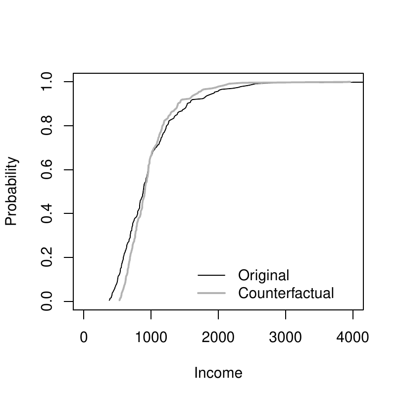

Figure 1: Observed and counterfactual distributions of income

```r
> library(quantreg)
> data(engel)
> attach(engel)
> counter_income <- mean(income)+0.75*(income-mean(income))
> cdfx <- c(1:length(income))/length(income)
> plot(c(0,4000),range(c(0,1)), xlim =c(0, 4000), type="n", xlab = "Income",
+      ylab="Probability")
> lines(sort(income), cdfx)
> lines(sort(counter_income), cdfx, lwd = 2, col = 'grey70')
> legend(1500, .2, c("Original", "Counterfactual"), lwd=c(1,2),bty="n",
+        col=c(1,'grey70'))
```

To estimate the QEs of this counterfactual change we turn on the option *transformation* of *counterfactual* by setting *transformation = TRUE*, and specify that the counterfactual values of the covariate *income* are in the generated variable *counter_income* by setting *counterfactual_var = counter_income*. This yields:

```r
> qrres <- counterfactual(foodexp~income, counterfactual_var
+         = counter_income, transformation = TRUE)

Conditional Model:                      linear quantile regression
Number of regressions estimated:         100

The variance has been estimated by bootstraping the results 100 times.

No. of obs. in the reference group:      235
No. of obs. in the counterfactual group: 235


                   Quantile Effects -- Composition
----------------------------------------------------------------------
                     Pointwise      Pointwise           Functional
 Quantile     Est.    Std.Err   95% Conf.Interval   95% Conf.Interval
     0.1    68.049     4.214    59.789    76.308    55.939    80.159
     0.2    57.897     4.332    49.406    66.388    45.448    70.346
     0.3    43.851     5.246    33.568    54.133    28.774    58.927
     0.4    29.248     5.091    19.270    39.227    14.618    43.878
     0.5    16.716     4.602     7.696    25.735     3.491    29.940
     0.6     5.744     4.308    -2.698    14.187    -6.634    18.123
     0.7    -8.866     7.132   -22.845     5.113   -29.361    11.630
     0.8   -40.099     8.191   -56.153   -24.045   -63.637   -16.561
     0.9    -88.56     13.83   -115.67    -61.44   -128.31    -48.80


      Bootstrap inference on the counterfactual quantile process
----------------------------------------------------------------------
                            P-values
                            ======================
NULL-Hypthoesis                          KS-statistic CMS-statistic
======================================================================
Correct specification of the parametric model          0          0
No effect: QE(tau)=0 for all taus                      0          0
Constant effect: QE(tau)=QE(0.5) for all taus          0          0
Stochastic dominance: QE(tau)>0 for all taus           0          0
Stochastic dominance: QE(tau)<0 for all taus           0          0
```

```r
> taus  <- c(1:99)/100
> first <- sum(as.double(taus <= .10))
> last  <- sum(as.double(taus <= .90))
> rang  <- c(first:last)
> rqres <- counterfactual(foodexp~income, counterfactual_var=counter_income,
+                         nreg=100, quantiles=taus, transformation = TRUE,
+                         printdeco = FALSE, sepcore = TRUE,ncore=2)

cores used= 2

> duqf   <- (rqres$resCE)[,1]
> l.duqf <- (rqres$resCE)[,3]
> u.duqf <- (rqres$resCE)[,4]
```

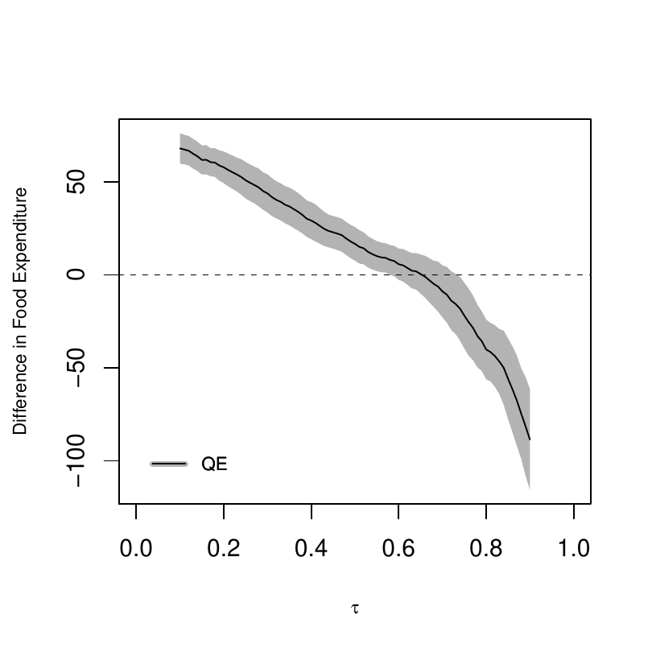

Figure 2: Quantile effects of income redistribution on food consumption

```r
> plot(c(0,1), range(c(min(l.duqf[rang]), max(u.duqf[rang]))), xlim = c(0,1),
+      type = "n", xlab = expression(tau), ylab = "Difference in Food Expenditure",
+      cex.lab=0.75)
> polygon(c(taus[rang], rev(taus[rang])), c(u.duqf[rang], rev(l.duqf[rang])),
+         density = -100, border = F, col = "grey70", lty = 1, lwd = 1)
> lines(taus[rang], duqf[rang])
> abline(h = 0, lty = 2)
> legend(0, -90, "QE", cex = 0.75, lwd = 4, bty = "n", col = "grey70")
> legend(0, -90, "QE", cex = 0.75, lty = 1, bty = "n", lwd = 1)
```

### 3.2 Union premium

We use an extract of the U.S. National Longitudinal Survey of Young Women (NLSW) for employed women in 1988 to estimate a wage decomposition with respect to union status.[^2] The outcome variable $Y$ is the log hourly wage (*lwage*), the covariates $X$ include job tenure in years (*tenure*), years of schooling (*grade*), and total experience (*ttl_exp*), and the union indicator *union* defines the reference and counterfactual populations. We estimate the conditional distributions by distribution regression with logistic link and duration regression, i.e., *method ="logit"* and *method ="cox"*. We use weighted bootstrap for the construction of uniform confidence intervals and hypothesis tests and run parallel computing with 2 nodes.

We start by estimating the wage decomposition by logistic distribution regression, where the counterfactual population is specified with *group=union* with the options *treatment=TRUE* and *decomposition=TRUE* to estimate the composition, structure and total effects. The structure effect in this case correspond to the treatment effect of union on the treated or union premium. The tables show that the union workers earn higher wages than the nonumion workers throuoghout the distribution although the union wage gap is decreasing in the quantile index. This gap can be mostly explained by differences in tenure, education and experience between union and nonunion workers in the upper tail of the distribution and by the union premium in the rest of the distribution.

```r
> data(nlsw88)
> attach(nlsw88)
> lwage    <- log(wage)
> logitres <- counterfactual(lwage~tenure+ttl_exp+grade,
+                           group = union, treatment=TRUE,
+                           decomposition=TRUE, method = "logit",
+                           weightedboot = TRUE, sepcore = TRUE, ncore=2)
cores used= 2

Conditional Model:                      logit
Number of regressions estimated:         96

The variance has been estimated by bootstraping the results 100 times.

No. of obs. in the reference group:      1407
No. of obs. in the counterfactual group: 459


                    Quantile Effects -- Structure
----------------------------------------------------------------------
                     Pointwise      Pointwise           Functional
 Quantile     Est.    Std.Err   95% Conf.Interval   95% Conf.Interval
     0.1   0.24047   0.06005   0.12278   0.35817   0.07757   0.40338
     0.2   0.21903   0.05630   0.10869   0.32937   0.06631   0.37176
     0.3   0.23437   0.04628   0.14366   0.32508   0.10881   0.35992
     0.4   0.18524   0.04252   0.10190   0.26857   0.06989   0.30059
     0.5   0.16041   0.04404   0.07410   0.24671   0.04095   0.27987
     0.6   0.13897   0.04618   0.04845   0.22949   0.01369   0.26425
     0.7   0.05701   0.04407  -0.02937   0.14339  -0.06255   0.17657
     0.8   0.01945   0.04179  -0.06245   0.10135  -0.09391   0.13281
     0.9  0.006434  0.078547 -0.147514  0.160382 -0.206650  0.219518


      Bootstrap inference on the counterfactual quantile process
----------------------------------------------------------------------
                            P-values
                            ======================
NULL-Hypthoesis                          KS-statistic CMS-statistic
======================================================================
Correct specification of the parametric model          1          1
No effect: QE(tau)=0 for all taus                      0          0
Constant effect: QE(tau)=QE(0.5) for all taus          0       0.02
Stochastic dominance: QE(tau)>0 for all taus        0.95       0.95
Stochastic dominance: QE(tau)<0 for all taus           0          0


                   Quantile Effects -- Composition
----------------------------------------------------------------------
                     Pointwise      Pointwise           Functional
 Quantile     Est.    Std.Err   95% Conf.Interval   95% Conf.Interval
     0.1   0.06062   0.04131  -0.02035   0.14160  -0.05752   0.17877
     0.2   0.04879   0.03717  -0.02406   0.12164  -0.05750   0.15508
     0.3   0.05313   0.03721  -0.01981   0.12607  -0.05329   0.15956
     0.4   0.09245   0.03772   0.01851   0.16638  -0.01543   0.20033
     0.5   0.08952   0.03945   0.01220   0.16683  -0.02329   0.20233
     0.6   0.12259   0.03862   0.04690   0.19828   0.01215   0.23303
     0.7   0.12975   0.03781   0.05564   0.20385   0.02162   0.23787
     0.8  0.090722  0.030184  0.031563  0.149881  0.004404  0.177041
     0.9   0.05503   0.05744  -0.05755   0.16760  -0.10924   0.21929


      Bootstrap inference on the counterfactual quantile process
----------------------------------------------------------------------
                            P-values
                            ======================
NULL-Hypthoesis                          KS-statistic CMS-statistic
======================================================================
Correct specification of the parametric model          1          1
No effect: QE(tau)=0 for all taus                   0.01       0.01
Constant effect: QE(tau)=QE(0.5) for all taus       0.77       0.58
Stochastic dominance: QE(tau)>0 for all taus        0.81       0.81
Stochastic dominance: QE(tau)<0 for all taus        0.01       0.01


                      Quantile Effects -- Total
----------------------------------------------------------------------
                     Pointwise      Pointwise           Functional
 Quantile     Est.    Std.Err   95% Conf.Interval   95% Conf.Interval
     0.1   0.30110   0.05703   0.18933   0.41287   0.13655   0.46565
     0.2   0.26782   0.06383   0.14271   0.39293   0.08363   0.45202
     0.3   0.28750   0.05459   0.18051   0.39449   0.12998   0.44502
     0.4   0.27768   0.05211   0.17556   0.37981   0.12733   0.42804
     0.5   0.24992   0.05111   0.14975   0.35010   0.10244   0.39741
     0.6   0.26156   0.04999   0.16358   0.35953   0.11731   0.40580
     0.7   0.18675   0.04529   0.09800   0.27551   0.05608   0.31743
     0.8   0.11017   0.04624   0.01954   0.20081  -0.02327   0.24361
     0.9   0.06146   0.06287  -0.06176   0.18468  -0.11996   0.24287


      Bootstrap inference on the counterfactual quantile process
----------------------------------------------------------------------
                            P-values
                            ======================
NULL-Hypthoesis                          KS-statistic CMS-statistic
======================================================================
Correct specification of the parametric model          1          1
No effect: QE(tau)=0 for all taus                      0          0
Constant effect: QE(tau)=QE(0.5) for all taus       0.06       0.13
Stochastic dominance: QE(tau)>0 for all taus        0.93       0.93
Stochastic dominance: QE(tau)<0 for all taus           0          0
```

```r
> taus  <- c(1:99)/100
> first <- sum(as.double(taus <= .10))
> last  <- sum(as.double(taus <= .90))
> rang  <- c(first:last)
> logitres <- counterfactual(lwage~tenure+ttl_exp+grade,
+           group = union, treatment=TRUE, quantiles=taus,
+           method="logit", nreg=100, weightedboot = TRUE,
+           printdeco=FALSE, decomposition = TRUE,
+           sepcore = TRUE,ncore=2)
cores used= 2
> duqf_SE   <- (logitres$resSE)[,1]
> l.duqf_SE <- (logitres$resSE)[,3]
> u.duqf_SE <- (logitres$resSE)[,4]
> duqf_CE   <- (logitres$resCE)[,1]
> l.duqf_CE <- (logitres$resCE)[,3]
> u.duqf_CE <- (logitres$resCE)[,4]
> duqf_TE   <- (logitres$resTE)[,1]
> l.duqf_TE <- (logitres$resTE)[,3]
> u.duqf_TE <- (logitres$resTE)[,4]
> range_x <- min(c(min(l.duqf_SE[rang]), min(l.duqf_CE[rang]),
+                 min(l.duqf_TE[rang])))
> range_y <- max(c(max(u.duqf_SE[rang]), max(u.duqf_CE[rang]),
+                 max(u.duqf_TE[rang])))
```

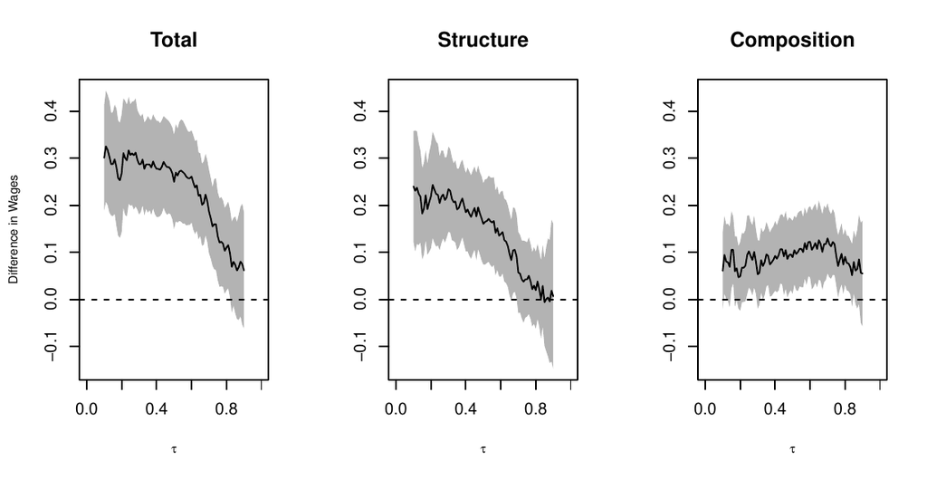

Figure 3: Wage decomposition with respect to union: logit regression estimates

```r
> par(mfrow=c(1,3))
> plot(c(0,1), range(c(range_x, range_y)), xlim = c(0,1), type = "n",
+      xlab = expression(tau), ylab = "Difference in Wages", cex.lab=0.75,
+      main = "Total")
> polygon(c(taus[rang],rev(taus[rang])),
+         c(u.duqf_TE[rang], rev(l.duqf_TE[rang])), density = -100, border = F,
+         col = "grey70", lty = 1, lwd = 1)
> lines(taus[rang], duqf_TE[rang])
> abline(h = 0, lty = 2)
> plot(c(0,1), range(c(range_x, range_y)), xlim = c(0,1), type = "n",
+      xlab = expression(tau), ylab = "", cex.lab=0.75, main = "Structure")
> polygon(c(taus[rang],rev(taus[rang])),
+         c(u.duqf_SE[rang], rev(l.duqf_SE[rang])), density = -100, border = F,
+         col = "grey70", lty = 1, lwd = 1)
> lines(taus[rang], duqf_SE[rang])
> abline(h = 0, lty = 2)
> plot(c(0,1), range(c(range_x, range_y)), xlim = c(0,1), type = "n",
+      xlab = expression(tau), ylab = "", cex.lab=0.75, main = "Composition")
> polygon(c(taus[rang],rev(taus[rang])),
+         c(u.duqf_CE[rang], rev(l.duqf_CE[rang])), density = -100, border = F,
+         col = "grey70", lty = 1, lwd = 1)
> lines(taus[rang], duqf_CE[rang])
> abline(h = 0, lty = 2)
```

```r
> coxres <- counterfactual(lwage~tenure+ttl_exp+grade,
+           group = union, treatment=TRUE, quantiles=taus,
+           method="cox", nreg=100, weightedboot = TRUE,
+           printdeco = FALSE, decomposition = TRUE, sepcore = TRUE,ncore=2)
cores used= 2
> duqf_SE   <- (coxres$resSE)[,1]
> l.duqf_SE <- (coxres$resSE)[,3]
> u.duqf_SE <- (coxres$resSE)[,4]
> duqf_CE   <- (coxres$resCE)[,1]
> l.duqf_CE <- (coxres$resCE)[,3]
> u.duqf_CE <- (coxres$resCE)[,4]
> duqf_TE   <- (coxres$resTE)[,1]
> l.duqf_TE <- (coxres$resTE)[,3]
> u.duqf_TE <- (coxres$resTE)[,4]
> range_x = min(c(min(l.duqf_SE[rang]), min(l.duqf_CE[rang]),
+                 min(l.duqf_TE[rang])))
> range_y = max(c(max(u.duqf_SE[rang]), max(u.duqf_CE[rang]),
+                 max(u.duqf_TE[rang])))
```

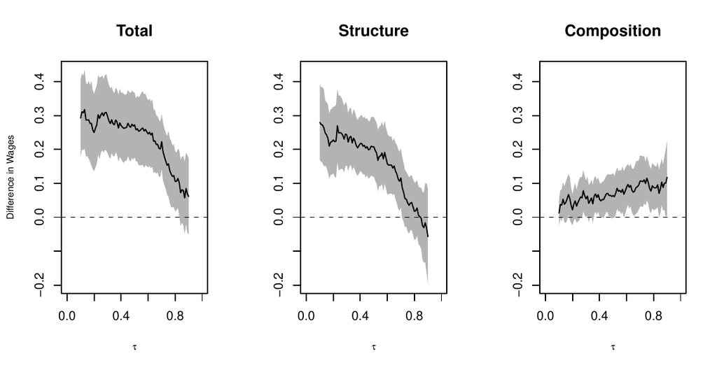

Figure 4: Wage decomposition with respect to union: duration regression estimates

```r
> par(mfrow=c(1,3))
> plot(c(0,1), range(c(range_x, range_y)), xlim = c(0,1), type = "n",
+      xlab = expression(tau), ylab = "Difference in Wages", cex.lab=0.75,
+      main = "Total")
> polygon(c(taus[rang],rev(taus[rang])),
+         c(u.duqf_TE[rang], rev(l.duqf_TE[rang])), density = -100, border = F,
+         col = "grey70", lty = 1, lwd = 1)
> lines(taus[rang], duqf_TE[rang])
> abline(h = 0, lty = 2)
> plot(c(0,1), range(c(range_x, range_y)), xlim = c(0,1), type = "n",
+      xlab = expression(tau), ylab = " ", cex.lab=0.75, main = "Structure")
> polygon(c(taus[rang],rev(taus[rang])),
+         c(u.duqf_SE[rang], rev(l.duqf_SE[rang])), density = -100, border = F,
+         col = "grey70", lty = 1, lwd = 1)
> lines(taus[rang], duqf_SE[rang])
> abline(h = 0, lty = 2)
> plot(c(0,1), range(c(range_x, range_y)), xlim = c(0,1), type = "n",
+      xlab = expression(tau), ylab = "", cex.lab=0.75, main = "Composition")
> polygon(c(taus[rang],rev(taus[rang])),
+         c(u.duqf_CE[rang], rev(l.duqf_CE[rang])), density = -100, border = F,
+         col = "grey70", lty = 1, lwd = 1)
> lines(taus[rang], duqf_CE[rang])
> abline(h = 0, lty = 2)
```

### 3.3 CRAN packages used

Counterfactual, quantreg, survival

### 3.4 CRAN Task Views implied by cited packages

CausalInference, ClinicalTrials, Econometrics, Environmetrics, Optimization, ReproducibleResearch, Robust, Survival

A. Blinder. Wage discrimination: Reduced form and structural estimates. *Journal of Human resources*, 436–455, 1973.

V. Chernozhukov, I. Fernández-Val and B. Melly. Inference on counterfactual distributions. *Econometrica*, 81(6): 2205–2268, 2013.

V. Chernozhukov and H. Hong. Three-step censored quantile regression and extramarital affairs. *Journal of the American Statistical Association*, 97(459): 872–882, 2002.

D. R. Cox. Regression models and life-tables. *Journal of the Royal Statistical Society B*, 34(2): 187–220, 1972.

R. Koenker. *Quantreg: Quantile regression.* 2016. URL https://CRAN.R-project.org/package=quantreg. R package version 5.21.

R. Koenker and G. Bassett. Regression quantiles. *Econometrica: journal of the Econometric Society*, 33–50, 1978.

R. Oaxaca. Male-female wage differentials in urban labor markets. *International economic review*, 693–709, 1973.

J. Stock. Nonparametric policy analysis: An application to estimating hazardous waste cleanup benefits. *Nonparametric and Semiparametric Methods in Econometrics and Statistics*, 77–98, 1991.

T. M. Therneau. *A package for survival analysis in s.* 2015. URL http://CRAN.R-project.org/package=survival. version 2.38.

[^1]: This is the same data set as in the quantile regression package *quantreg*, see (Koenker 2016).
[^2]: This dataset is available from the Stata’s sample datasets at *http://www.stata-press.com/data/r9/nlsw88.dta*.